# Segmentation: Hidden Markov Models

# Segmentation: Hidden Markov Models

EFB 796: Techniques in Movement Ecology

Elie Gurarie

October 2, 2025

# Goals

> To estimate a Multi-State Random Walk for some elk data, using the #' `momentuhmm` package.

Useful packages:

```r
require(plyr)
#' require(mapview)
#' require(sf)
#' require(ggplot2)
```

And load the *regularized* elk data here: elk_regdata.rda.

```r
head(elk_regdata)
```

```
##      id                date       lon      lat
#' ## 1  YL96 2004-03-29 17:00:00 -115.5565 51.74235
#' ## 3  YL96 2004-03-29 19:00:00 -115.5819 51.75622
#' ## 5  YL96 2004-03-29 21:00:00 -115.5929 51.73834
#' ## 7  YL96 2004-03-29 23:00:00 -115.5971 51.73432
#' ## 9  YL96 2004-03-30 01:00:00 -115.6028 51.73174
#' ## 11 YL96 2004-03-30 03:00:00 -115.5991 51.73254
```

# Select Individuals (Non-Residential)

We can one of the visualization methods we learned to examine the #' tracks for non-residential (migratory) behavior.

```r
ggplot(data=elk_regdata, aes(x=lon, y=lat)) +
#'   geom_path(size=0.5) +
#'   theme_classic() +
#'   facet_wrap(~id, scale="free", ncol=4)
```

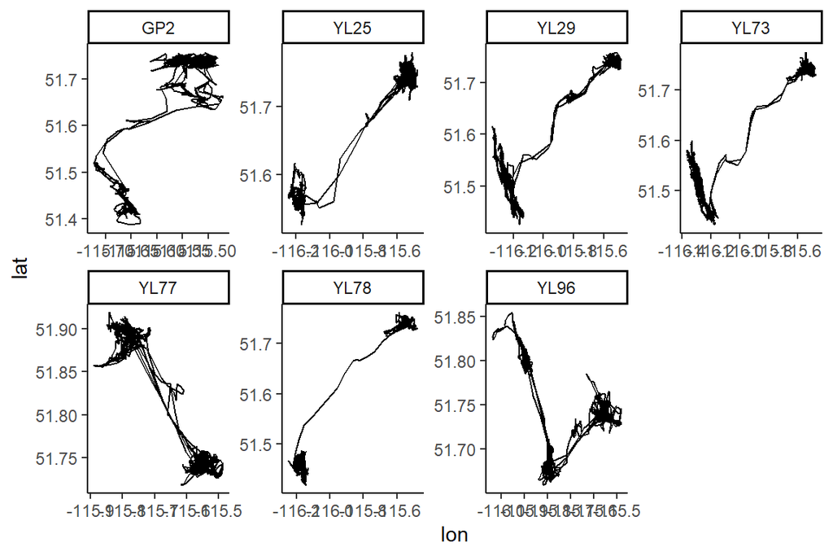

This subset of animals has fairly clear migratory movements. We’ll #' see if we can parse those movements even more finely.

NOTE: this version of the elk data has been “regularized” at 2 hour #' intervals. Here’s one way to see that:

```r
dlply(elk_regdata, "id",
#'       function(df) summary(diff(df$date)))
```

```
## $GP2
#' ## Time differences in hours
#' ##    Min. 1st Qu.  Median    Mean 3rd Qu.    Max.
#' ##       2       2       2       2       2       2
#' ##
#' ## $YL25
#' ## Time differences in hours
#' ##    Min. 1st Qu.  Median    Mean 3rd Qu.    Max.
#' ##       2       2       2       2       2       2
#' ##
#' ## $YL29
#' ## Time differences in hours
#' ##    Min. 1st Qu.  Median    Mean 3rd Qu.    Max.
#' ##       2       2       2       2       2       2
#' ##
#' ## $YL73
#' ## Time differences in hours
#' ##    Min. 1st Qu.  Median    Mean 3rd Qu.    Max.
#' ##       2       2       2       2       2       2
#' ##
#' ## $YL77
#' ## Time differences in hours
#' ##    Min. 1st Qu.  Median    Mean 3rd Qu.    Max.
#' ##       2       2       2       2       2       2
#' ##
#' ## $YL78
#' ## Time differences in hours
#' ##    Min. 1st Qu.  Median    Mean 3rd Qu.    Max.
#' ##       2       2       2       2       2       2
#' ##
#' ## $YL96
#' ## Time differences in hours
#' ##    Min. 1st Qu.  Median    Mean 3rd Qu.    Max.
#' ##       2       2       2       2       2       2
#' ##
#' ## attr(,"split_type")
#' ## [1] "data.frame"
#' ## attr(,"split_labels")
#' ##     id
#' ## 1  GP2
#' ## 2 YL25
#' ## 3 YL29
#' ## 4 YL73
#' ## 5 YL77
#' ## 6 YL78
#' ## 7 YL96
```

# Hidden Markov Model

Hidden Markov Models (HMMs) can be used for time series data to #' describe 2 processes, one observed (e.g., the data produced by #' telemetry, such as locations and movement metrics) and one “hidden”, #' representing the “hidden” ecological behaviors driving the observed #' data.

The Markov chain portion of HMM’s state that the probability of being #' in a particular behavior state at time $t+1$ is **only** dependent on #' the current state at time $t$. Once #' these probabilities are described, a transition probability matrix, or #' the probability of moving between behavior states, can be described. #' HMM’s can have any number of hidden behavioral states, granted that they #' are biologically meaningful (model selection can also assist with #' determining the “optimal” number of states).

Importantly, HMMs are performed in discrete time and assume that #' observations are “conditionally independent”. These can be difficult for #' movement data derived from tags, which can be prone to irregularly #' spaced observations and errors.

## Load the data

Now that our data is regular space/time, we can use the methods we #' learned in lab 2 to make our data spatial, convert the coordinates to a #' projected coordinate system, and save the X/Y coordinates as columns in #' our data.

```r
library(sf)
```

Prepare

```r
myelk_utm <- elk_regdata |> subset(id == "YL96") |>
#'   st_as_sf(coords = c("lon","lat"), crs = 4326) |>
#'   st_transform(32611)
```

We will need the coordinates! But the data should be a data frame

```r
myelk_utm <- cbind(myelk_utm, st_coordinates(myelk_utm)) |> data.frame()
#' head(myelk_utm)
```

```
##      id                date        X       Y                 geometry
#' ## 1  YL96 2004-03-29 17:00:00 599661.1 5733368 POINT (599661.1 5733368)
#' ## 3  YL96 2004-03-29 19:00:00 597878.1 5734876 POINT (597878.1 5734876)
#' ## 5  YL96 2004-03-29 21:00:00 597157.1 5732873 POINT (597157.1 5732873)
#' ## 7  YL96 2004-03-29 23:00:00 596874.3 5732420 POINT (596874.3 5732420)
#' ## 9  YL96 2004-03-30 01:00:00 596492.0 5732126   POINT (596492 5732126)
#' ## 11 YL96 2004-03-30 03:00:00 596745.6 5732220 POINT (596745.6 5732220)
```

## Fit HMM: Two States

Now that our data is regularized and we have our movement metrics #' annotated to our data, we can fit our HMM with the #' `momentuHMM` package, which is very flexible. You can use #' user-specified parameter distributions, options for hierarchical and #' multivariate models, biased correlated random walks and more. As usual, #' read the [vignette](https://cran.r-project.org/web/packages/momentuHMM/vignettes/momentuHMM.pdf).

```r
library(momentuHMM)
```

We first prepare our data using the `prepData` function to #' grab our X/Y coordinates.

```r
myelk_hmm_prep <- prepData(myelk_utm |> data.frame(),
#'                            type = "UTM", coordNames = c("X","Y"))
#'
#' head(myelk_hmm_prep)
```

```
##        ID      step       angle   id                date
#' ## 1 Animal1 2335.3893          NA YL96 2004-03-29 17:00:00
#' ## 2 Animal1 2129.0133  1.92742231 YL96 2004-03-29 19:00:00
#' ## 3 Animal1  533.8463 -0.21297386 YL96 2004-03-29 21:00:00
#' ## 4 Animal1  482.5415 -0.35596210 YL96 2004-03-29 23:00:00
#' ## 5 Animal1  270.6406  2.84203213 YL96 2004-03-30 01:00:00
#' ## 6 Animal1 1300.5587 -0.08190792 YL96 2004-03-30 03:00:00
#' ##                   geometry        x       y
#' ## 1 POINT (599661.1 5733368) 599661.1 5733368
#' ## 2 POINT (597878.1 5734876) 597878.1 5734876
#' ## 3 POINT (597157.1 5732873) 597157.1 5732873
#' ## 4 POINT (596874.3 5732420) 596874.3 5732420
#' ## 5   POINT (596492 5732126) 596492.0 5732126
#' ## 6 POINT (596745.6 5732220) 596745.6 5732220
```

Note that once again - this package made a data frame that computes #' all the things we computed, and `ltraj` computes.

It is important that step lengths be greater than 0:

```r
table(myelk_hmm_prep$step == 0)
```

```
##
#' ## FALSE
#' ##  2421
```

MomentuHMM fits HMM’s within a Bayesian framework, where prior #' distributions can be specified for each state-specific parameter to help #' distinguish the “true” behavioral state when combined with observed #' distributions.

We will start with a two-state model with state-specific and #' distribution specific parameters for each variable that will be used to #' distinguish our behavioral states, namely the step length and relative #' turning angles.

We will make our priors somewhat informative, assuming that one state #' will be defined by smaller step lengths (smaller mean and sd) and bigger #' turning angles (smaller concentration parameter), with the opposite for #' the second state.

```r
stepMean0 <- c(m1 = 100, m2 = 4000)
#' stepSD0 <- c(sd1 = 50, sd2 = 1000)
#' angleCon0 <- c(rho1  = 0.1, rho2 = 0.8)
```

We will now assign names to our states, with the slower, more #' tortuous state being defined as a “resident” state and the faster, #' straighter state as a “transit” state.

```r
stateNames <- c("resident","transit")
```

We now pick distributions for our variables of interest (step length #' and turning angle), using a Gamma distribution for the step lengths #' (`?dgamma`) and a Wrapped Cauchy distribution for the turning #' angles (`dwrpcauchy`).

We store our priors defined in the code chunk above into a list #' object, “Par0”.

```r
dist <- list(step = "gamma", angle = "wrpcauchy")
#' Par0 <- list(step=c(stepMean0, stepSD0), angle = c(angleCon0))
```

We can now fit our HMM using the `fitHMM` function with #' our prepped data and objects from above. We also specify the number of #' states to identify (`nbStates`).

```r
myelk_hmm_fit <- fitHMM(data = myelk_hmm_prep, nbStates = 2, dist = dist,
#'                       Par0 = Par0, stateNames = stateNames)
#'
#' print(myelk_hmm_fit)
```

```
## Value of the maximum log-likelihood: -20243.62
#' ##
#' ##
#' ## step parameters:
#' ## ----------------
#' ##      resident  transit
#' ## mean 128.1198 672.7852
#' ## sd   104.3393 550.0250
#' ##
#' ## angle parameters:
#' ## -----------------
#' ##                resident   transit
#' ## mean          0.0000000 0.0000000
#' ## concentration 0.1966112 0.6733005
#' ##
#' ## Regression coeffs for the transition probabilities:
#' ## ---------------------------------------------------
#' ##               1 -> 2     2 -> 1
#' ## (Intercept) -1.27182 -0.8936554
#' ##
#' ## Transition probability matrix:
#' ## ------------------------------
#' ##           resident   transit
#' ## resident 0.7810542 0.2189458
#' ## transit  0.2903561 0.7096439
#' ##
#' ## Initial distribution:
#' ## ---------------------
#' ##     resident      transit
#' ## 4.182165e-06 9.999958e-01
```

After fitting our model, we can use the Viterbi formula with the #' `viterbi` function to decode the transition probabilities for #' the most likely states at each time point along our movement #' trajectory.

```r
hmm_states <- viterbi(myelk_hmm_fit)
#' str(hmm_states)
```

```
##  int [1:2422] 2 2 2 2 2 2 2 2 2 2 ...
```

We can add our predicted states as a column for each observation to #' our data:

```r
myelk_utm$state <- hmm_states
```

### Plot 2-state predictions

The default plotting of `momentuhmm` is quite useful:

```
## Decoding state sequence... DONE
```

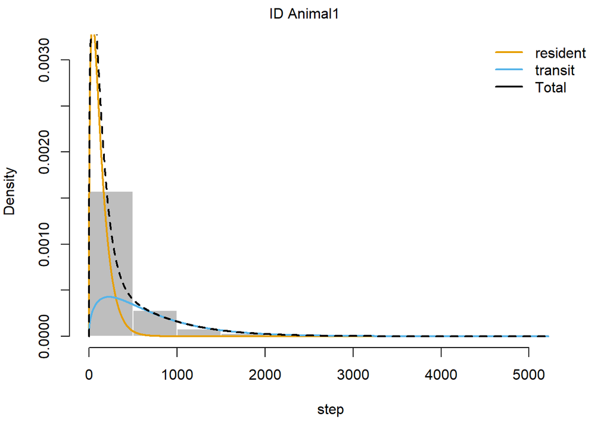

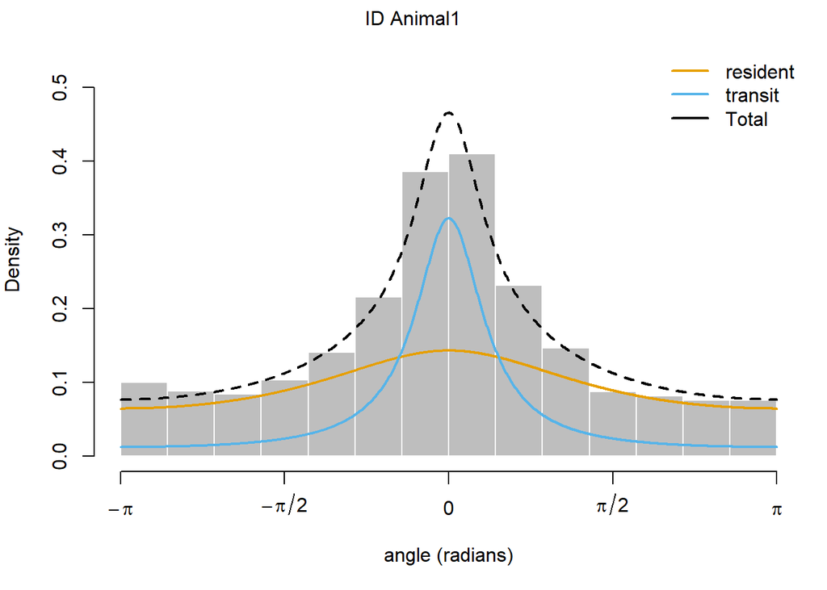

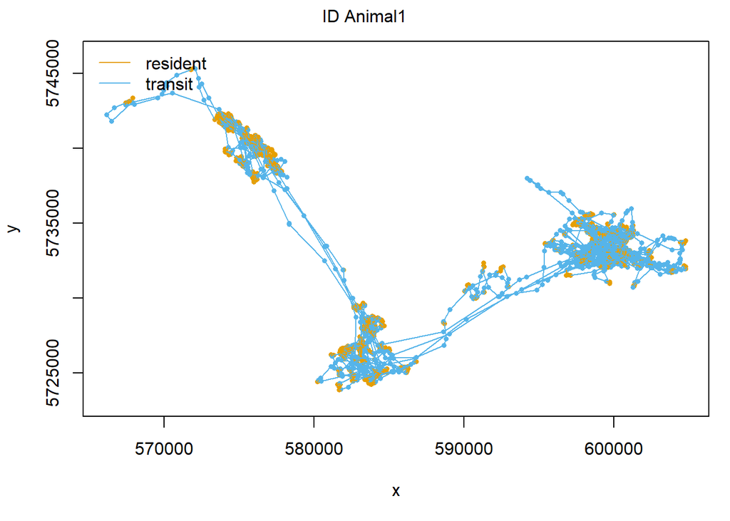

```r
## plot(myelk_hmm_fit)
```

We can then plot the results, using Base R to make multidimensional #' plots of the trajectory with the annotated states:

```r
layout(cbind(c(1,1),2:3))
#' par(bty = "l", mar = c(2,2,2,2))
#'
#' with(myelk_utm, {
#'   plot(X, Y, asp =1, col = c("orange","blue")[state], pch = 19, cex = 0.7)
#'   segments(X[-length(X)], Y[-length(Y)],
#'            X[-1], Y[-1], col = c("orange","blue")[state[-length(state)]])
#'   plot(date, X, col = c("orange","blue")[state], pch = 19, cex = 0.7)
#'   segments(date[-length(X)], Y[-length(Y)],
#'            date[-1], Y[-1], col = c("orange","blue")[state[-length(state)]])
#'   plot(date, Y, col = c("orange","blue")[state], pch = 19, cex = 0.7)
#'   segments(date[-length(X)], Y[-length(Y)],
#'            date[-1], Y[-1], col = c("orange","blue")[state[-length(state)]])
#' })
```

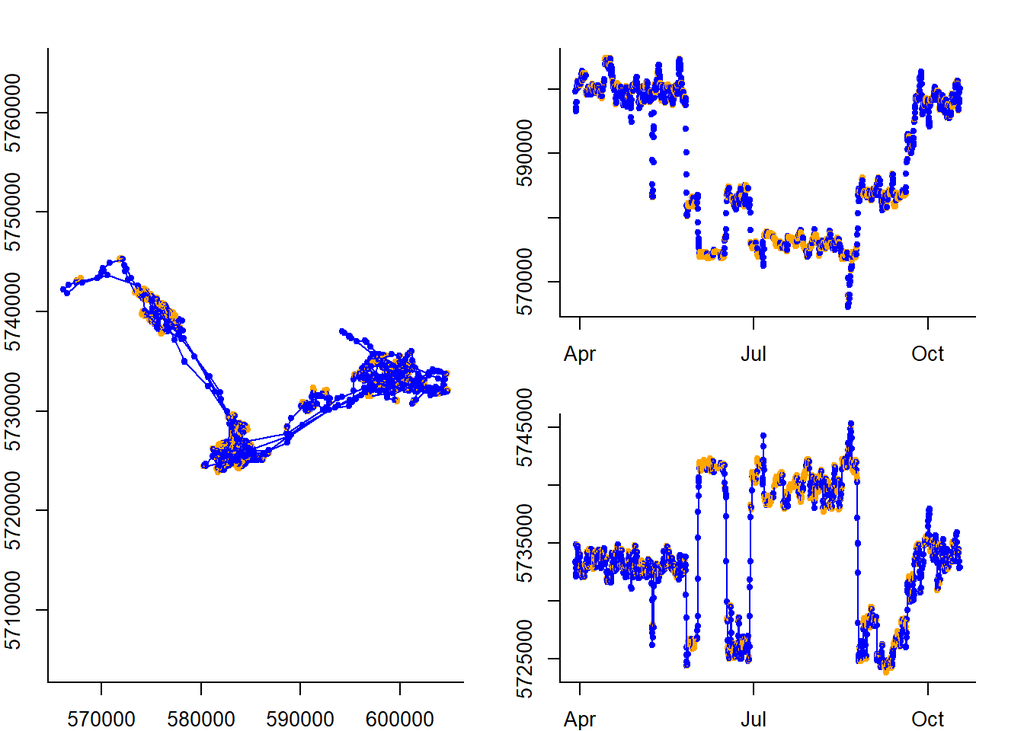

We can also convert our data to an sf structure and use the methods #' we learned in lab 1 to plot the trajectory with each location colored by #' the predicted state with the mapview package.

```r
library(mapview)
```

```r
myelk_sf <- myelk_utm |>
#'   st_as_sf(coords=c("X","Y"), crs= 32611) |>
#'   st_transform(4326) |>
#'   mutate(state = as.character(state))
#'
#' myelk_track <- myelk_sf |>
#'   dplyr::summarize(do_union=FALSE) |>
#'   st_cast("LINESTRING")
#'
#' require(mapview)
#' mapview(myelk_track, color="darkgrey") +
#'   mapview(myelk_sf, zcol="state",
#'           col.regions=c("orange","blue"))
```

[interactive chart not shown]

This may suggest that there are actually 3 behavioral states here: #' one that is fast and straight (blue state), one that is slower and #' tortuous (orange state), and a third that is intermediate, where the #' animal is having directed, faster movements within its residential #' patch.

## Fit HMM: 3-State Model

We can fit a 3 state model by simply adding an additional #' state-specific prior for each movement variable.

```r
stepMean0 <- c(m1 = 50, m2 = 2000, m3 = 200)
#' stepSD0 <- c(sd1 = 50, sd2 = 1000, sd3 = 100)
#' angleCon0 <- c(rho1  = 0.1, rho2 = 0.8, rho3 = 0.2)
```

We will label this third state as an additional “faster” residential #' state.

```r
stateNames <- c("resident-slow","transit", "resident-faster")
```

```r
dist <- list(step = "gamma", angle = "wrpcauchy")
#' Par0 <- list(step=c(stepMean0, stepSD0), angle = c(angleCon0))
```

We re-fit the model as before, but this time specifying 3 states.

```r
myelk_hmm_threestate <- fitHMM(data = myelk_hmm_prep, nbStates = 3,
#'                          dist = dist, Par0 = Par0,
#'                          stateNames = stateNames,
#'                          formula = ~1)
```

```r
myelk_hmm_threestate
```

```
## Value of the maximum log-likelihood: -20092.3
#' ##
#' ##
#' ## step parameters:
#' ## ----------------
#' ##      resident-slow  transit resident-faster
#' ## mean     102.18263 2093.951        466.2833
#' ## sd        78.50869 1045.552        307.2800
#' ##
#' ## angle parameters:
#' ## -----------------
#' ##               resident-slow   transit resident-faster
#' ## mean              0.0000000 0.0000000       0.0000000
#' ## concentration     0.1555154 0.7988476       0.6222665
#' ##
#' ## Regression coeffs for the transition probabilities:
#' ## ---------------------------------------------------
#' ##                1 -> 2    1 -> 3    2 -> 1     2 -> 3    3 -> 1    3 -> 2
#' ## (Intercept) -71.59147 -0.956773 -54.78336 0.04184581 -0.809652 -2.581995
#' ##
#' ## Transition probability matrix:
#' ## ------------------------------
#' ##                 resident-slow      transit resident-faster
#' ## resident-slow    7.224752e-01 5.848459e-32       0.2775248
#' ## transit          7.900909e-25 4.895401e-01       0.5104599
#' ## resident-faster  2.926492e-01 4.973117e-02       0.6576196
#' ##
#' ## Initial distribution:
#' ## ---------------------
#' ##   resident-slow         transit resident-faster
#' ##    4.113229e-06    9.999959e-01    2.225694e-08
```

We can decode our model results and bind the predicted states for #' each observation back to our data:

```r
hmm_3states <- viterbi(myelk_hmm_threestate)
#' myelk_utm$state <- hmm_3states
```

```
## Decoding state sequence... DONE
```

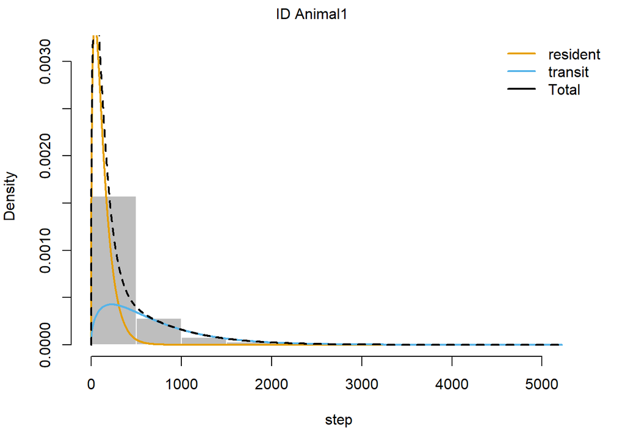

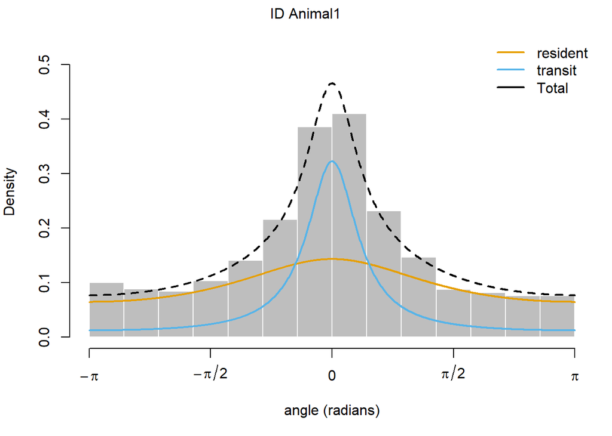

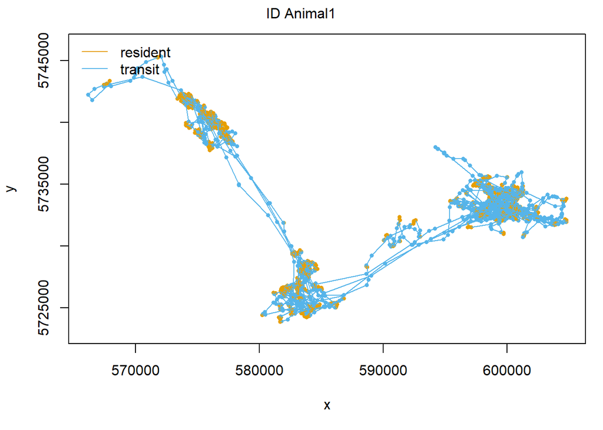

```r
## plot(myelk_hmm_fit)
```

Here is a mapview:

```r
myelk_track <- myelk_sf |>
#'   dplyr::summarize(do_union=FALSE) |>
#'   st_cast("LINESTRING")
#' myelk_sf <- myelk_sf |> mutate(state = hmm_3states)
#' mapview(myelk_track, color="darkgrey") +
#'   mapview(myelk_sf, zcol="state", col.regions=c("orange","blue", "green"))
```

[interactive chart not shown]